Analysis of Relationship Between Player Injuries and NFL Combine Results and Other Statistics, 2009-2016 by Seth Farnsworth ========================================================

This is data I gleaned from multiple sources with contains information on NFL players, to include their NFL combine measurements (height, weight, speed, etc.), ages, various performance statistics, and games missed due to injury per season of their career. My main interest here is in looking at potential correlations between injury rates and the other aforementioned variables. As an avid NFL fan, I know that injuries play a vital and unpredictable role in the success of each NFL franchise each season. So I thought it would be fun to look at some different variables that might have a role in player injury rates, and see if anything interesting jumps out as we explore the data.

There are three datasets I’m using for this–one with injury data for each player per season from 2009-2016; one for NFL combine measurements for players from 1999-2015; and another with NFL statistics including birthdates, career performance statistics (passing yards, receptions, rushing average, etc.) and draft data (round, position).

As this data did not exists as a unified, clean dataset prior to this project, I had to do a fair bit of work to gather and clean the data prior to performing this exploratory analysis in R. For details on that process, you can see my write-up on that [here](https://github.com/sethfarns/udacity-data-analyst-nanodegree/blob/master/exploratory-data-analysis-with-r/Wrangle%2BFootball%2BStatistics%2BData.html).

# Univariate Plots Section

```
## 'data.frame':    1295 obs. of  18 variables:
##  $ X                : int  0 1 2 4 5 6 8 10 13 14 ...
##  $ arms             : num  0 0 0 0 0 0 0 0 0 0 ...
##  $ bench            : num  24 12 19 13 11 0 0 23 22 22 ...
##  $ broad            : num  130 0 121 121 121 122 111 122 0 0 ...
##  $ fortyyd          : num  4.6 4.42 4.57 4.43 4.53 4.56 5.03 4.56 0 4.8 ...
##  $ hands            : num  0 0 0 0 0 0 0 0 0 0 ...
##  $ heightinchestotal: num  69 72 72 68 72 72 78 75 74 76 ...
##  $ tenyd            : num  0 0 0 0 0 0 0 0 0 0 ...
##  $ threecone        : num  6.79 0 7.1 6.64 6.96 7.09 7.2 7.07 0 0 ...
##  $ twentyss         : num  3.95 0 4.1 4.07 4.28 4.03 4.19 4.03 0 0 ...
##  $ twentyyd         : num  0 0 0 0 0 0 0 0 0 0 ...
##  $ vertical         : num  42.5 0 39 34 35.5 35.5 30 37 0 0 ...
##  $ weight           : int  205 198 221 180 221 218 294 243 236 282 ...
##  $ year             : int  2015 2015 2015 2015 2015 2015 2015 2015 2015 2015 ...
##  $ Player           : Factor w/ 1290 levels "A.J. Cann","A.J. Derby",..: 41 955 587 855 585 14 509 1145 954 1170 ...
##  $ Pos              : Factor w/ 17 levels "C","CB","DE",..: 14 17 14 17 14 6 3 7 10 3 ...
##  $ injured_pct      : num  0.44 0.19 0.25 0.06 0.06 0.03 0.31 0.16 0.81 1 ...
##  $ position_group   : Factor w/ 10 levels "DB","DL","FB",..: 7 10 7 10 7 1 2 4 4 2 ...
```

```
## 'data.frame':    5936 obs. of  8 variables:
##  $ X             : int  0 1 2 3 4 5 6 7 8 9 ...
##  $ Player        : Factor w/ 1981 levels "A.J. Cann","A.J. Derby",..: 1 2 3 3 3 4 4 4 4 4 ...
##  $ Pos           : Factor w/ 23 levels "C","CB","DB",..: 13 22 11 11 11 23 23 23 23 23 ...
##  $ season        : int  2015 2016 2011 2012 2014 2011 2012 2013 2014 2015 ...
##  $ Total_Games   : int  16 16 16 16 16 16 16 16 16 16 ...
##  $ Total_Injured : num  0 1 4 16 3 1 0 0 3 0 ...
##  $ position_group: Factor w/ 10 levels "DB","DL","FB",..: 5 9 4 4 4 10 10 10 10 10 ...
##  $ age           : num  23 24 23 24 26 23 24 25 26 27 ...
```

```
## 'data.frame':    1981 obs. of  33 variables:
##  $ X             : int  0 1 2 3 4 6 7 8 9 10 ...
##  $ AV            : int  80 17 79 89 48 28 21 5 4 35 ...
##  $ Cmp.          : num  NA NA NA NA NA NA NA NA NA NA ...
##  $ DOB           : Factor w/ 1663 levels "1976-03-27","1976-03-31",..: 649 478 530 110 934 307 1387 698 878 562 ...
##  $ End_Year      : int  2015 2015 2016 2012 2016 2013 2016 2010 2015 2013 ...
##  $ FF            : int  NA NA NA NA NA NA NA 0 NA NA ...
##  $ FGA           : int  NA NA NA NA NA NA NA NA NA NA ...
##  $ FGM           : int  NA NA NA NA NA NA NA NA NA NA ...
##  $ FantPt        : num  1591 NA NA NA NA ...
##  $ G             : int  127 99 126 136 115 107 42 30 43 92 ...
##  $ GS            : int  NA NA 123 132 NA NA 37 NA NA NA ...
##  $ Int           : int  NA 13 NA NA 22 NA NA NA NA 15 ...
##  $ Player        : Factor w/ 1981 levels "A.J. Cann","A.J. Derby",..: 1353 1978 1660 486 1937 1858 1799 1469 1096 723 ...
##  $ Pos           : Factor w/ 23 levels "C","CB","DB",..: 19 3 1 1 3 22 16 11 3 3 ...
```

[output cut: 19 more lines]

```
##        X               arms           bench           broad
##  Min.   :   0.0   Min.   : 0.00   Min.   : 0.00   Min.   :  0.00
##  1st Qu.: 638.5   1st Qu.: 0.00   1st Qu.: 0.00   1st Qu.:105.00
##  Median :1293.0   Median : 0.00   Median :18.00   Median :115.00
##  Mean   :1588.6   Mean   :12.78   Mean   :15.35   Mean   : 97.06
##  3rd Qu.:2356.5   3rd Qu.:32.00   3rd Qu.:24.00   3rd Qu.:121.00
##  Max.   :4930.0   Max.   :37.75   Max.   :49.00   Max.   :147.00
##
##     fortyyd          hands        heightinchestotal     tenyd
##  Min.   :0.000   Min.   : 0.000   Min.   :65.00     Min.   :0.0000
##  1st Qu.:4.480   1st Qu.: 0.000   1st Qu.:72.00     1st Qu.:0.0000
##  Median :4.620   Median : 0.000   Median :74.00     Median :0.0000
##  Mean   :4.381   Mean   : 3.773   Mean   :73.83     Mean   :0.2874
##  3rd Qu.:4.840   3rd Qu.: 9.250   3rd Qu.:76.00     3rd Qu.:0.0000
##  Max.   :5.710   Max.   :11.120   Max.   :80.25     Max.   :1.9200
##
##    threecone        twentyss        twentyyd         vertical
##  Min.   :0.000   Min.   :0.000   Min.   :0.0000   Min.   : 0.00
##  1st Qu.:0.000   1st Qu.:0.000   1st Qu.:0.0000   1st Qu.:29.25
##  Median :0.000   Median :4.200   Median :0.0000   Median :33.00
##  Mean   :2.995   Mean   :3.168   Mean   :0.1821   Mean   :29.21
##  3rd Qu.:7.000   3rd Qu.:4.400   3rd Qu.:0.0000   3rd Qu.:36.00
##  Max.   :8.310   Max.   :5.270   Max.   :2.7800   Max.   :45.00
##
##      weight         year                  Player          Pos
##  Min.   :164   Min.   :1999   Adrian Peterson:   2   WR     :269
##  1st Qu.:208   1st Qu.:2008   Ben Obomanu    :   2   RB     :188
##  Median :230   Median :2011   Mike Williams  :   2   DE     :156
##  Mean   :240   Mean   :2010   Ricky Williams :   2   DT     :146
##  3rd Qu.:266   3rd Qu.:2014   Steve Smith    :   2   TE     :124
##  Max.   :369   Max.   :2015   A.J. Cann      :   1   CB     : 97
##                               (Other)        :1284   (Other):315
##   injured_pct     position_group
##  Min.   :0.0000   DL     :302
##  1st Qu.:0.0600   WR     :269
##  Median :0.1600   RB     :188
##  Mean   :0.2264   DB     :140
##  3rd Qu.:0.3100   TE     :124
##  Max.   :1.0000   QB     : 96
##                   (Other):176
```

```
##        X                    Player          Pos           season
##  Min.   :   0   Aaron Rodgers  :   8   DB     : 947   Min.   :2009
##  1st Qu.:1484   Adrian Peterson:   8   WR     : 834   1st Qu.:2011
##  Median :2968   Aqib Talib     :   8   LB     : 638   Median :2013
##  Mean   :2968   Ben Watson     :   8   RB     : 583   Mean   :2013
##  3rd Qu.:4451   Brandon Flowers:   8   DE     : 566   3rd Qu.:2014
##  Max.   :5935   Brian Cushing  :   8   DT     : 482   Max.   :2016
##                 (Other)        :5888   (Other):1886
##   Total_Games Total_Injured    position_group      age
##  Min.   :16   Min.   : 0.000   DB     :1347   Min.   :15.0
##  1st Qu.:16   1st Qu.: 0.000   DL     :1121   1st Qu.:23.0
##  Median :16   Median : 1.000   LB     : 846   Median :25.0
##  Mean   :16   Mean   : 3.341   WR     : 834   Mean   :25.8
##  3rd Qu.:16   3rd Qu.: 4.000   RB     : 583   3rd Qu.:28.0
##  Max.   :16   Max.   :16.000   TE     : 435   Max.   :39.0
##                                (Other): 770
```

```
##        X              AV              Cmp.               DOB
##  Min.   :   0   Min.   :  0.00   Min.   :40.00   1990-02-24:   5
##  1st Qu.: 551   1st Qu.:  3.00   1st Qu.:56.77   1991-02-22:   5
##  Median :1101   Median : 12.00   Median :59.65   1987-03-22:   4
##  Mean   :1100   Mean   : 21.46   Mean   :59.27   1988-06-27:   4
##  3rd Qu.:1644   3rd Qu.: 30.00   3rd Qu.:61.90   1989-04-26:   4
##  Max.   :2199   Max.   :236.00   Max.   :90.00   1989-07-10:   4
##                                  NA's   :1887    (Other)   :1955
##     End_Year          FF              FGA            FGM
##  Min.   :2009   Min.   : 0.000   Min.   : 14    Min.   :10
##  1st Qu.:2012   1st Qu.: 1.000   1st Qu.: 36    1st Qu.:29
##  Median :2015   Median : 3.000   Median : 58    Median :48
##  Mean   :2014   Mean   : 4.826   Mean   : 58    Mean   :48
##  3rd Qu.:2016   3rd Qu.: 6.000   3rd Qu.: 80    3rd Qu.:67
##  Max.   :2016   Max.   :46.000   Max.   :102    Max.   :86
##                 NA's   :1492     NA's   :1979   NA's   :1979
##      FantPt             G                GS             Int
##  Min.   :  -1.1   Min.   :  1.00   Min.   :  1.0   Min.   :  0.00
##  1st Qu.:  67.4   1st Qu.: 28.00   1st Qu.:  3.0   1st Qu.:  5.00
##  Median : 202.5   Median : 54.00   Median :  9.0   Median : 11.00
##  Mean   : 399.8   Mean   : 64.46   Mean   : 21.4   Mean   : 21.76
##  3rd Qu.: 517.1   3rd Qu.: 94.00   3rd Qu.: 28.0   3rd Qu.: 21.00
##  Max.   :4171.1   Max.   :237.00   Max.   :203.0   Max.   :220.00
##  NA's   :1310     NA's   :14       NA's   :1646    NA's   :1649
##             Player          Pos          QBrec           Rec
##  A.J. Cann     :   1   WR     :275          :1889   Min.   :   1
##  A.J. Derby    :   1   DB     :258   0-1-0  :   3   1st Qu.:  34
##  A.J. Edds     :   1   RB     :208   0-0-0  :   2   Median :  99
##  A.J. Green    :   1   LB     :197   1-1-0  :   2   Mean   : 171
##  A.J. Hawk     :   1   DE     :186   20-27-0:   2   3rd Qu.: 236
##  A.J. Jefferson:   1   DT     :163   0-10-0 :   1   Max.   :1125
##  (Other)       :1975   (Other):694   (Other):  82   NA's   :1576
##       Ret               Rt              Rush              Sk
##  Min.   :  2.00   Min.   :  2.00   Min.   :   1.0   Min.   :  1.50
##  1st Qu.: 16.00   1st Qu.:  9.00   1st Qu.:  80.0   1st Qu.:  4.50
##  Median : 39.00   Median : 24.50   Median : 224.0   Median :  9.50
##  Mean   : 60.15   Mean   : 42.48   Mean   : 446.5   Mean   : 17.43
##  3rd Qu.: 88.00   3rd Qu.: 58.75   3rd Qu.: 617.0   3rd Qu.: 23.50
##  Max.   :276.00   Max.   :231.00   Max.   :3174.0   Max.   :138.50
##  NA's   :1948     NA's   :1915     NA's   :1768     NA's   :1492
```

[output cut: 17 more lines]

```
##  Min.   :  1.00   Min.   :1.000   Min.   :2008   DB     :423
##  1st Qu.: 41.00   1st Qu.:2.000   1st Qu.:2008   DL     :373
##  Median : 86.00   Median :3.000   Median :2008   LB     :293
##  Mean   : 97.05   Mean   :3.381   Mean   :2008   WR     :275
##  3rd Qu.:144.00   3rd Qu.:5.000   3rd Qu.:2008   RB     :208
##  Max.   :257.00   Max.   :7.000   Max.   :2008   OL     :156
##  NA's   :400      NA's   :400     NA's   :400    (Other):253
##   injured_pct
##  Min.   :0.000
##  1st Qu.:0.060
##  Median :0.160
##  Mean   :0.232
##  3rd Qu.:0.310
##  Max.   :1.000
##
```

Our injuries data set contains 5,936 observations of 8 variables. The combine data set contains 1,295 observations of 18 variables, and the stats dataset contains 1,981 observations of 33 variables. There are more observations for the injury dataset because it contains injury data for each season of the players’ careers, while the other two datasets cover their entire careers. The injury data needed to be seasonal in order to measure the effect of age on injury rates season-by-season. These are all relationable tables, with ‘Player’ and ‘Pos’ the common keys between the three tables. The ‘Pos’ field is the primary factor variable we’ll be exploring with these three datasets. There is also a ‘position_group’ factor, which is just a condensing of the position variable (from 23 options down to 10).

```
## [1] "Total_Injured"
##    Min. 1st Qu.  Median    Mean 3rd Qu.    Max.
##   0.000   0.000   1.000   3.341   4.000  16.000
```

```
## [1] "injured_pct"
##    Min. 1st Qu.  Median    Mean 3rd Qu.    Max.
##  0.0000  0.0600  0.1600  0.2264  0.3100  1.0000
```

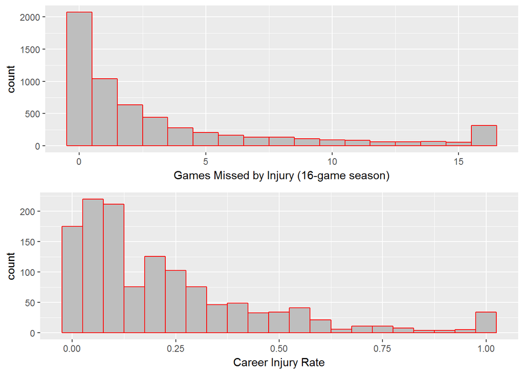

Let’s take a look at player age in another histogram.

```
## [1] "age"
##    Min. 1st Qu.  Median    Mean 3rd Qu.    Max.
##    15.0    23.0    25.0    25.8    28.0    39.0
```

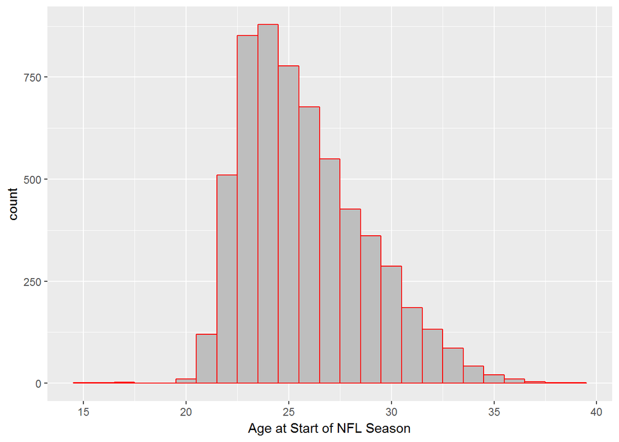

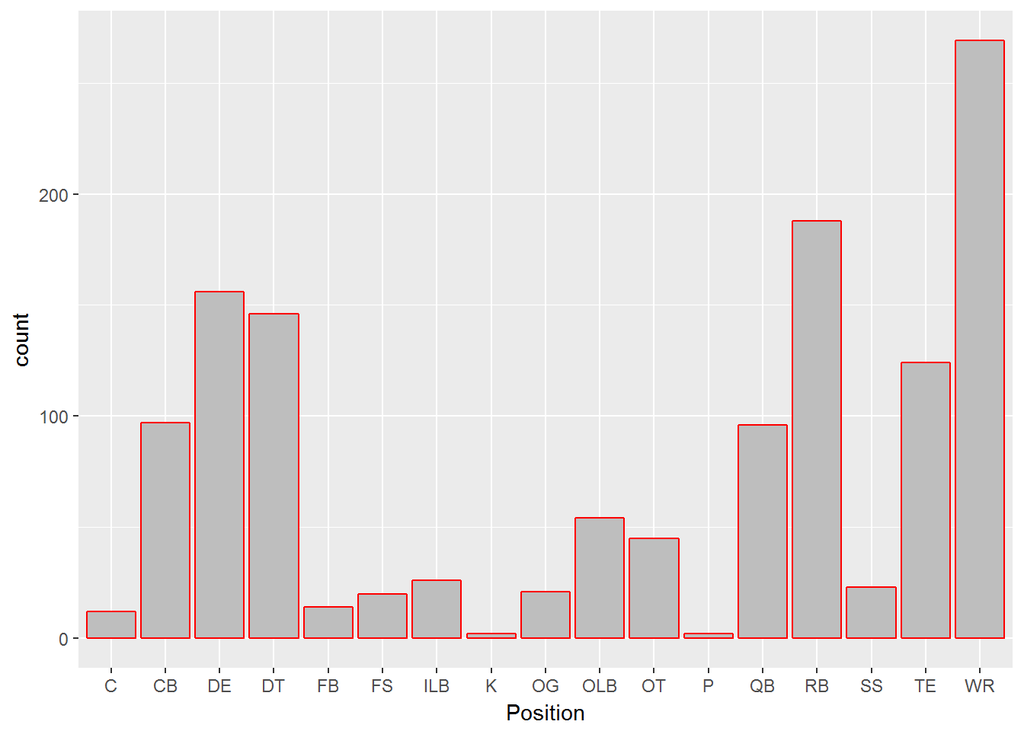

```
##   C  CB  DE  DT  FB  FS ILB   K  OG OLB  OT   P  QB  RB  SS  TE  WR
##  12  97 156 146  14  20  26   2  21  54  45   2  96 188  23 124 269
```

Lots of wide receivers and running backs (teams typically carry 3-6 of each), not so many kickers and punters (each team carries just 1). So there’s nothing surprising here. Now let’s look at the measurables height, weight, arm length, and hand size.

```
## [1] "heightinchestotal"
##    Min. 1st Qu.  Median    Mean 3rd Qu.    Max.
##   65.00   72.00   74.00   73.83   76.00   80.25
```

```
## [1] "weight"
##    Min. 1st Qu.  Median    Mean 3rd Qu.    Max.
##     164     208     230     240     266     369
```

```
## [1] "arms"
##    Min. 1st Qu.  Median    Mean 3rd Qu.    Max.
##   28.00   31.38   32.50   32.44   33.50   37.75
```

```
## [1] "hands"
##    Min. 1st Qu.  Median    Mean 3rd Qu.    Max.
##   7.500   9.120   9.500   9.544  10.000  11.120
```

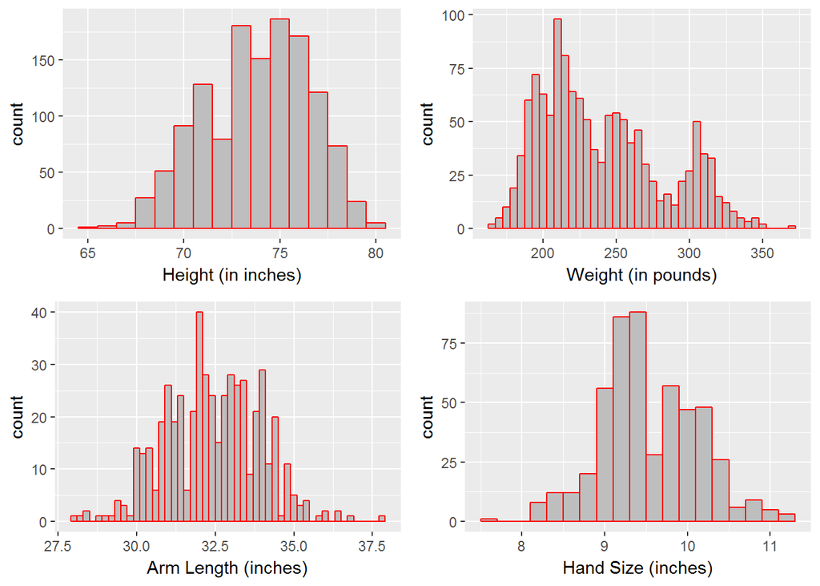

Arm length and hand size appear to be mostly normal distributions. It is worth noting that these two measurements were not available for all players, as is also the case with most of the combine drills that we’ll look at next.

```
## [1] "bench"
##    Min. 1st Qu.  Median    Mean 3rd Qu.    Max.
##    3.00   17.00   21.00   21.26   25.00   49.00
```

```
## [1] "broad"
##    Min. 1st Qu.  Median    Mean 3rd Qu.    Max.
##    74.0   111.0   117.0   115.9   122.0   147.0
```

```
## [1] "vertical"
##    Min. 1st Qu.  Median    Mean 3rd Qu.    Max.
##   20.50   31.00   34.00   33.66   36.00   45.00
```

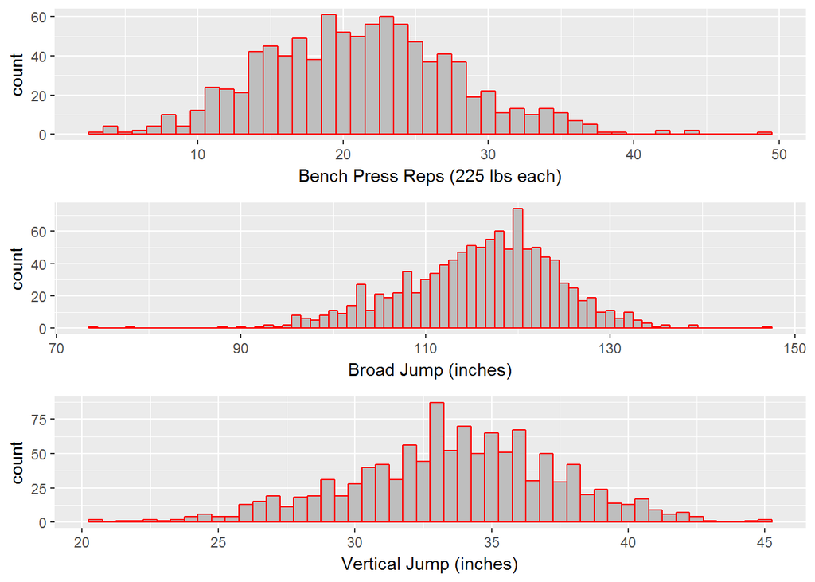

Our first three plots of the combine fitness test results–bench press, broad jump, and vertical jump–all show relatively normal distributions. There are some significant outliers on these, especially on the lower end of the broad jump.

```
## [1] "tenyd"
##    Min. 1st Qu.  Median    Mean 3rd Qu.    Max.
##   1.400   1.520   1.570   1.584   1.630   1.920
```

```
## [1] "twentyyd"
##    Min. 1st Qu.  Median    Mean 3rd Qu.    Max.
##   2.290   2.530   2.590   2.592   2.650   2.780
```

```
## [1] "fortyyd"
##    Min. 1st Qu.  Median    Mean 3rd Qu.    Max.
##   4.240   4.510   4.650   4.704   4.870   5.710
```

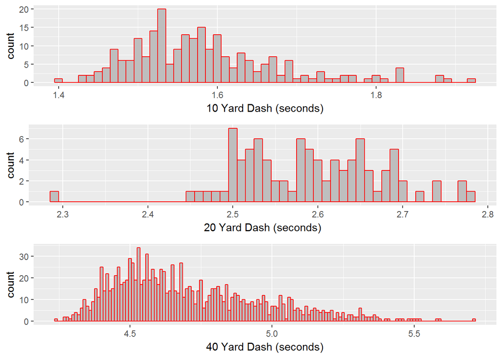

Here we have the three straight-line speed tests–the 10-yard, 20-yard, and 40-yard dashes. The 40-yard dash is by far the most well known, and it’s also the one that players train the most for prior to the combine, which probably explains why there’s so much more data for that test than for the others.

The 40-yard dash data is clearly skewed right. The 10-yard and 20-yard dashes are also skewed right, though it’s harder to see, likely because of the lack of data relative to the 40-yard dash totals.

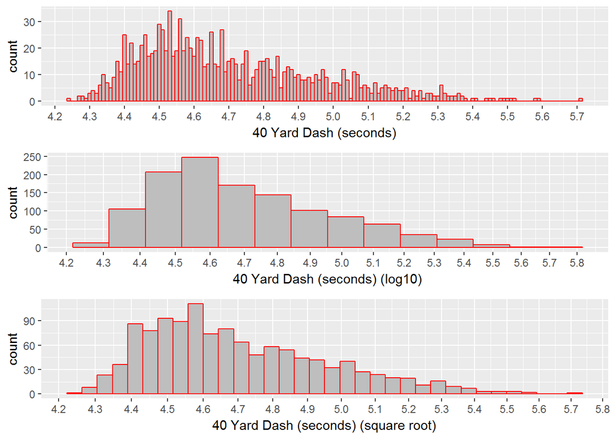

When looking at the 40-yard dash distribution next to its log10 and square root transformations, you can see how smooth the distribution is with the transformations.

```
## [1] "twentyss"
##    Min. 1st Qu.  Median    Mean 3rd Qu.    Max.
##   3.760   4.170   4.300   4.332   4.470   5.270
```

```
## [1] "threecone"
##    Min. 1st Qu.  Median    Mean 3rd Qu.    Max.
##   6.300   6.880   7.070   7.117   7.260   8.310
```

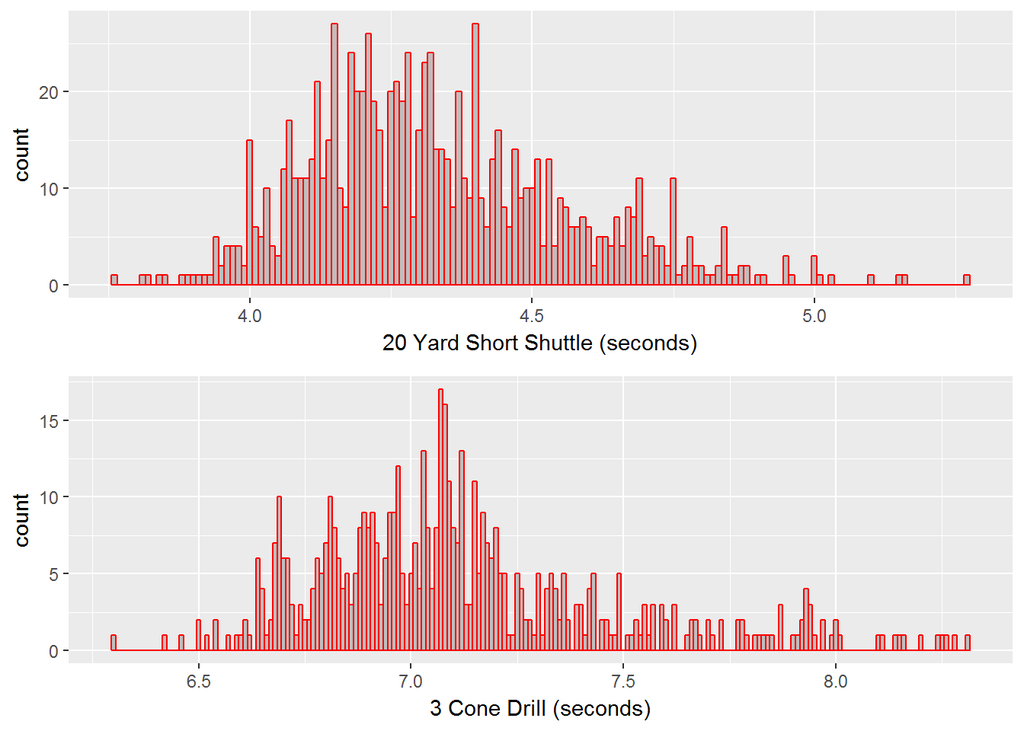

These last two tests, the 20-yard short shuttle and the 3-cone drill, measure agility and change of direction ability. These mostly look like unimodal normal distributions, with maybe a slight skew to the right, although with the short shuttle there are some other peaks in there, notably at 4.0, 4.4, and around 4.75 seconds. Now let’s look at some NFL player statistics.

```
## [1] "Yds"
##    Min. 1st Qu.  Median    Mean 3rd Qu.    Max.
##      22    2396    6257   12559   18246   66111
```

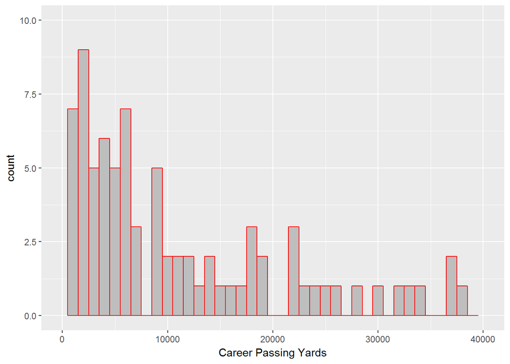

```
## [1] "Yds"
##    Min. 1st Qu.  Median    Mean 3rd Qu.    Max.
##       8     356     950    1974    2506   13684
```

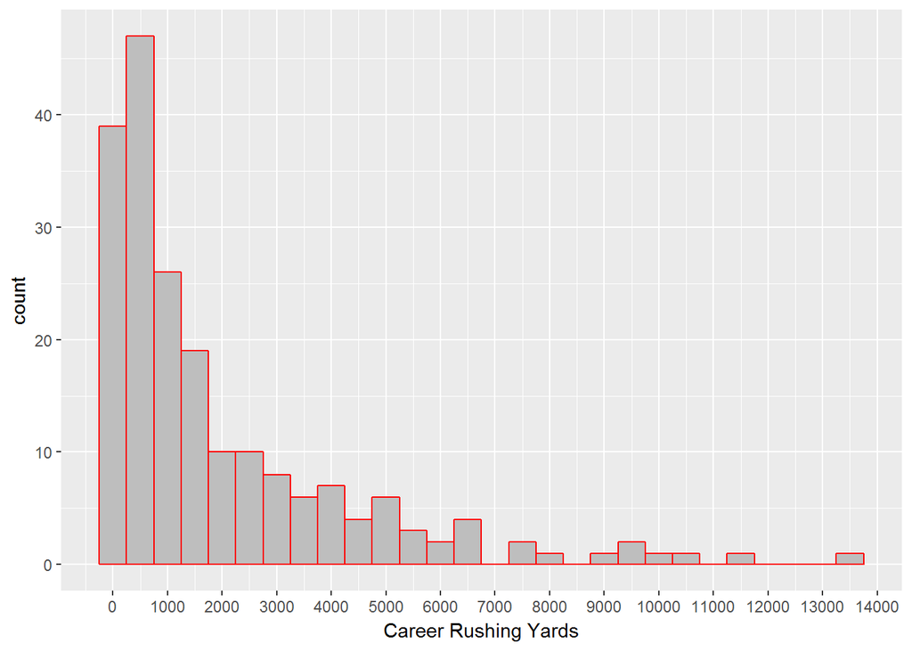

Again, another skewed-right long-tail distribution. We do have a much bigger sample size here than with the passing yards, which makes sense, as there are a lot more NFL players who rush the ball than throw it, especially when you consider that most quarterbacks would also register on this statistic. But I think to get a better view of these career statistics, it will be more useful to try and average these over each season of a player’s career.

```
## [1] "yards_per_season"
##     Min.  1st Qu.   Median     Mean  3rd Qu.     Max.
##    9.429  426.750 1053.200 1498.106 2258.114 4189.000
```

```
## [1] "yards_per_season"
##    Min. 1st Qu.  Median    Mean 3rd Qu.    Max.
##     4.0   107.0   263.2   348.2   547.6  1244.0
```

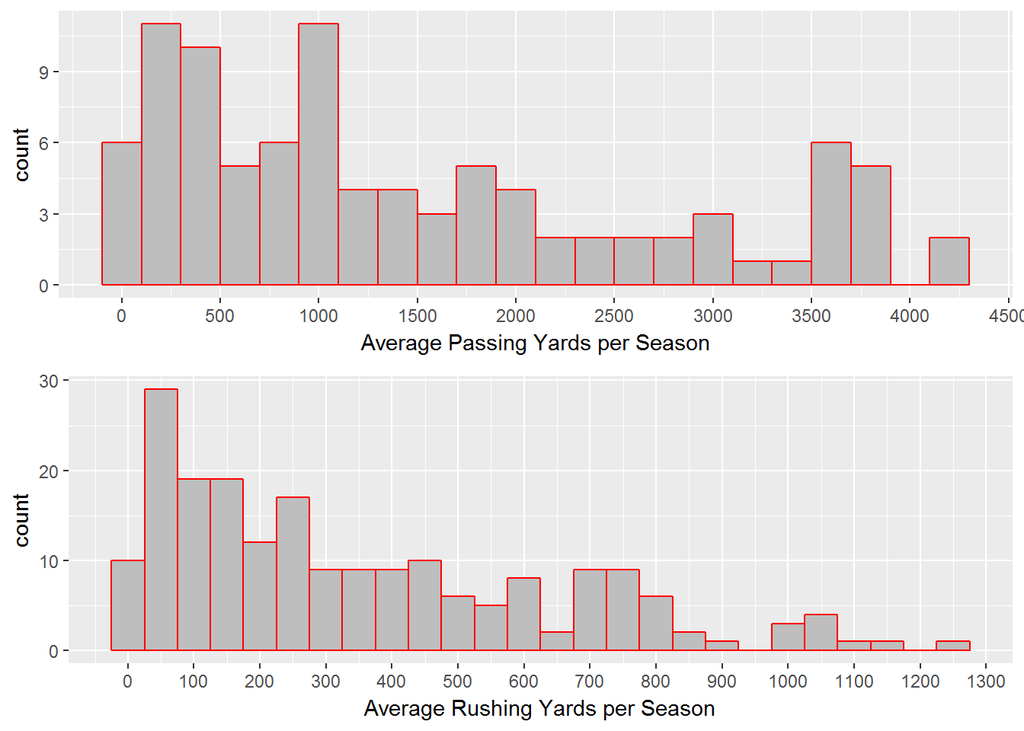

The plot for average passing yards is mostly skewed-right, but there is also a slight uptick after about 3,000 yards. Average rushing yards is a smoother distribution, probably in part because there’s a much larger sample size.

Let’s do one more plot to look at draft position

```
## [1] "Draft_Pick"
##    Min. 1st Qu.  Median    Mean 3rd Qu.    Max.
##    1.00   41.00   86.00   97.05  144.00  257.00
```

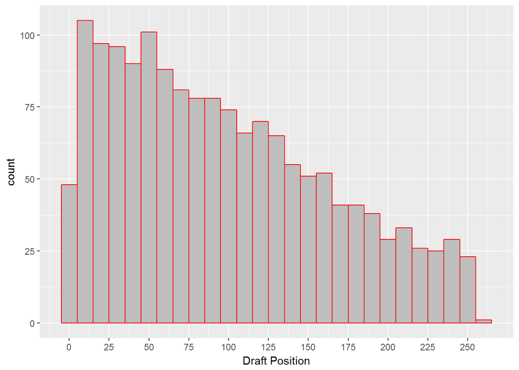

Again, another long-tail, skewed-right distribution. It’s interesting that while one player is picked at each position in the draft each year, this plot shows there are far more early picks in the NFL than late picks. Multiple factors could explain this, including just the general talent level of early draft picks versus later ones.

# Univariate Analysis

### What is the structure of your dataset?

We have thousands of players in three different datasets, comprising injury data per season, NFL combine data, birth dates, draft data, and various career statistics. For our combine measurements, the plots are primarily normal distributions, while for player statistics, injuries, and draft position, we’re looking at mainly skewed-right long-tail histograms.

### What is/are the main feature(s) of interest in your dataset?

The primary feature of interest to me in this dataset is the number of games missed due to injury by each player in each season. While there are other observations to be made on this data, and as this is an exploratory data analysis I don’t want to miss anything by being too heavily biased toward one thing, but injuries are such a huge and seemingly unpredictable part of the NFL. If we could find some correlation between age or any of the combine measurements and a player’s injury rate, that would be really interesting, in my opinion.

### What other features in the dataset do you think will help support your investigation into your feature(s) of interest?

The age at the beginning of each NFL season and the various combine measurements will all be helpful for my investigation of player injury rates. I would actually be shocked if age didn’t have some correation to injury rates. I also think things like height and weight will have some correlation, but it will probably vary by position. At least that would be my guess. I’ll also look a bit at how injury rates affect players’ performance and longevity.

### Did you create any new variables from existing variables in the dataset?

Yes, I had to create player age at the beginning of each season, by subtracting the year of the player’s birth from the current season. This was done in order to measure the effect of age on games missed due to injury. I also created position_group from the Position variable, in order to condense the number of factors to better players by position group (this will be done later). Another variable I created for the univariate analysis specifically was average yards per season for both passing yards and rushing yards.

### Of the features you investigated, were there any unusual distributions? Did you perform any operations on the data to tidy, adjust, or change the form of the data? If so, why did you do this?

Yes, I had to do a lot of this, as the data came from three different sources (several different CSV files from two different websites, with the rest scraped from [Pro Football Reference](https://www.pro-football-reference.com/)). Full details on this are available in my separate report you can view on GitHub, but the data from the different datasets had to be changed so they would correlate with each other. For example, in the data from Pro Football Reference, many players were listed with multiple positions, while the injury and combine data only listed one position for each player. In order to get the data to correlate across the data sets, I had to flatten out the PFR data, by making one record for each position listed for each player, then joining it with the other data sets on player and position.

# Bivariate Plots Section

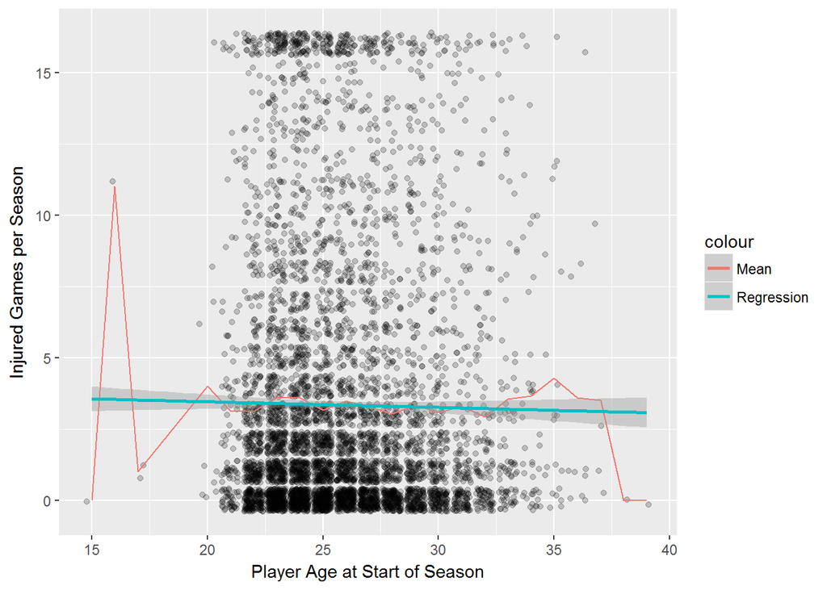

```
## [1] "Correlation:"
```

```
## [1] -0.01315911
```

Somewhat surprisingly, there is clearly very little correlation between player age at the beginning of the season and games missed due to injury. There are a lot of factors that could be at play here–when an older player gets hurt, often he won’t be signed by any team and basically ‘retires’ at that point. Those cases won’t show in the data. Also, injuries occur for a variety of reasons, many being freak accidents that wouldn’t correlate to age. To see a true correlation, we would need data for injured players who get released or don’t get signed by any teams due to injury, as well as categories of injuries. Let’s look next at the various combine measurements and see what correlations exist between them.

It is worth noting, however, that when looking at the mean line, you can see that there is noticeable increase with players from around 32 to 35 years of age and. Let’s look at a subset of that data to see if there is a stronger correlation.

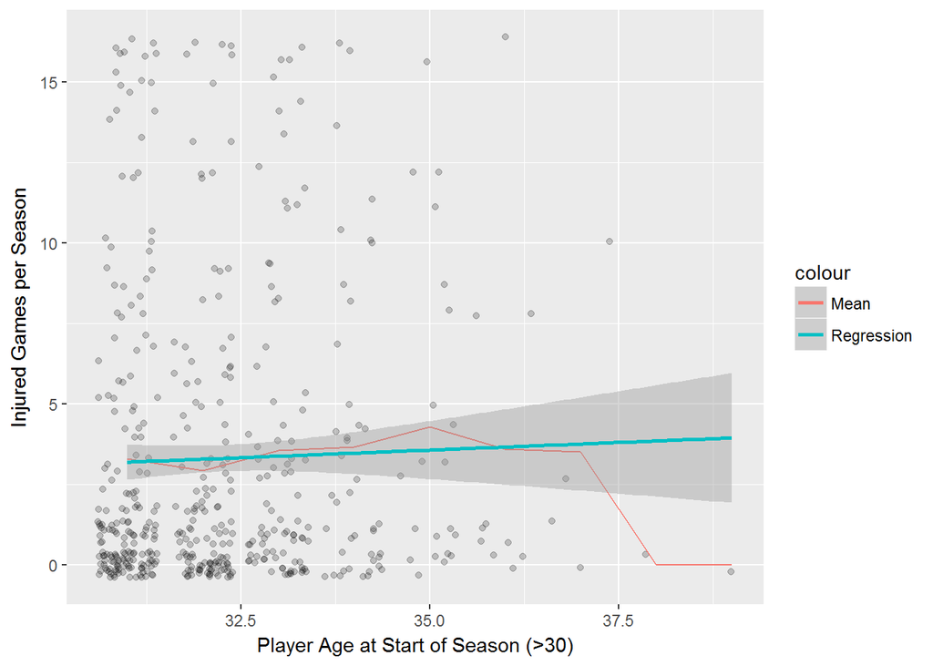

```
## [1] -0.01315911
```

```
## [1] 0.02895316
```

Here you can see a slightly greater correlation (0.03 vs. -0.01 for all the data), but the difference is very slight.

Can we find correlations between injury rates and others of our variables? Let’s look at a few of them now.

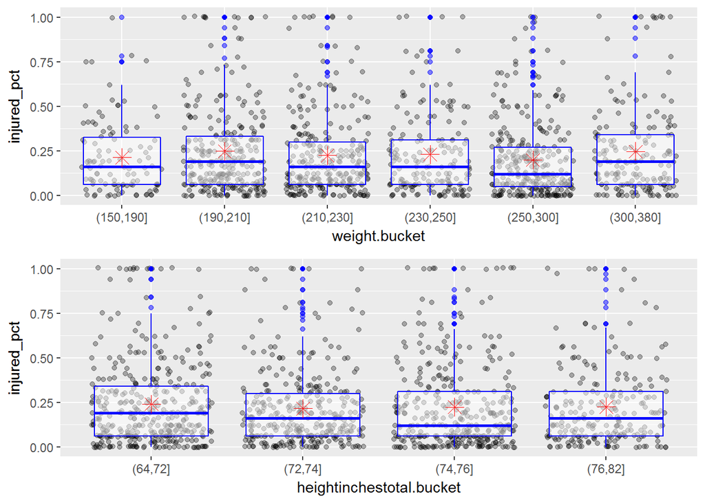

```
## [1] "Weight to injured percentage:"
```

```
## [1] -0.009361038
```

```
## [1] "Height to injured percentage:"
```

```
## [1] -0.03074242
```

Clearly not much correlation for these, but I wonder what it would look like to compute density as weight divided by height, and see how that correlates to other variables.

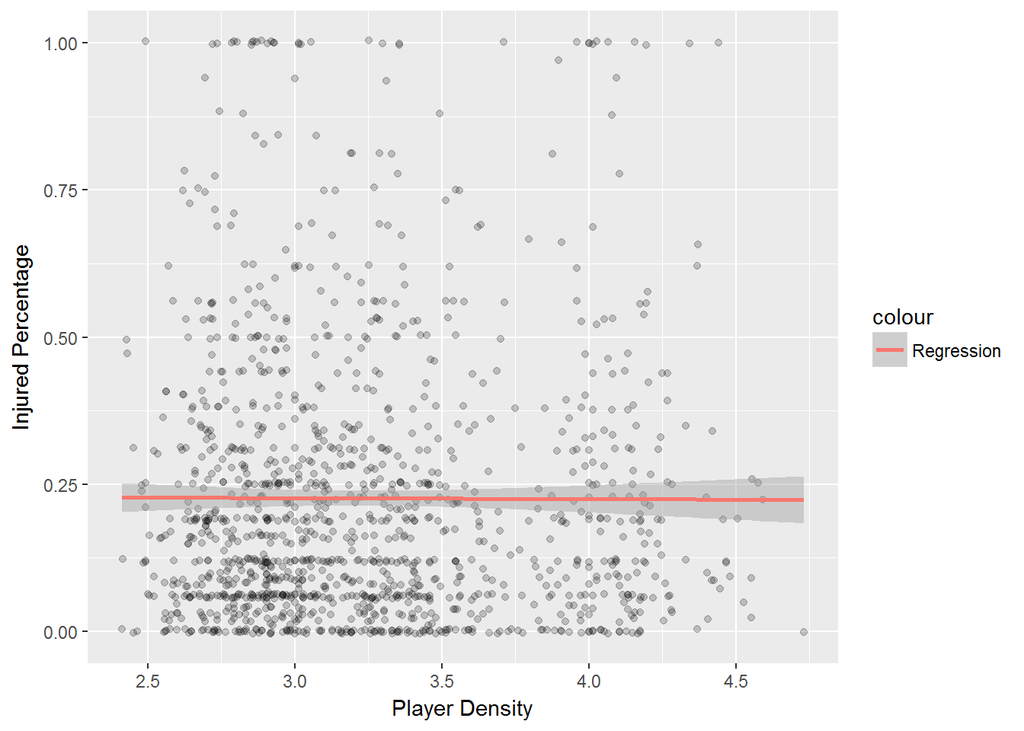

```
## [1] "Density to injured percentage:"
```

```
## [1] -0.003523474
```

Okay, so even when using a composite statistic for weight and height, we’re not going to be able to correlate this to percentage of games missed over player’s career. Possibly a dead end, but we’ll see what these look like later when we break them down by position. Let’s switch gears a bit and take a more generic look at correlations between our various features and see what we can find. We’ll start with the combine measurements.

```
##                    arms       bench       broad    vertical     fortyyd
## arms         1.00000000  0.02031146  0.06412837  0.06132334  0.04918271
## bench        0.02031146  1.00000000  0.01639414  0.01508274  0.12349110
## broad        0.06412837  0.01639414  1.00000000  0.79049737  0.44633157
## vertical     0.06132334  0.01508274  0.79049737  1.00000000  0.47968444
## fortyyd      0.04918271  0.12349110  0.44633157  0.47968444  1.00000000
## hands        0.99491286  0.01853529  0.05839890  0.06131512  0.05102561
## tenyd        0.49999533 -0.04082160  0.18125208  0.11195799  0.09944209
## threecone    0.19750609  0.01077485  0.34142956  0.31365010  0.16543197
## twentyss     0.07200314  0.04135874  0.55636376  0.54472649  0.38852382
## twentyyd     0.21375460 -0.10826797  0.13908229  0.15291489  0.02419385
## injured_pct  0.01305542  0.01110568 -0.01382213 -0.01128857 -0.02901010
## density     -0.08360423  0.45667734 -0.20094745 -0.23641003  0.06126445
##                    hands       tenyd    threecone    twentyss
## arms         0.994912865  0.49999533  0.197506091  0.07200314
## bench        0.018535287 -0.04082160  0.010774851  0.04135874
## broad        0.058398904  0.18125208  0.341429557  0.55636376
## vertical     0.061315123  0.11195799  0.313650102  0.54472649
## fortyyd      0.051025608  0.09944209  0.165431972  0.38852382
## hands        1.000000000  0.49613191  0.197132966  0.07357391
## tenyd        0.496131910  1.00000000  0.350478467  0.11058859
## threecone    0.197132966  0.35047847  1.000000000  0.40561999
## twentyss     0.073573908  0.11058859  0.405619990  1.00000000
## twentyyd     0.213491538  0.56492661  0.253903784  0.10906962
## injured_pct  0.009847923 -0.01984628 -0.000412589 -0.01646117
## density     -0.082354532 -0.12322076 -0.105786942 -0.00501125
##                  twentyyd   injured_pct      density
## arms         0.2137546012  0.0130554239 -0.083604234
## bench       -0.1082679722  0.0111056765  0.456677341
## broad        0.1390822925 -0.0138221320 -0.200947449
## vertical     0.1529148888 -0.0112885750 -0.236410030
## fortyyd      0.0241938539 -0.0290101047  0.061264455
## hands        0.2134915383  0.0098479227 -0.082354532
## tenyd        0.5649266090 -0.0198462810 -0.123220756
## threecone    0.2539037838 -0.0004125890 -0.105786942
## twentyss     0.1090696224 -0.0164611694 -0.005011250
## twentyyd     1.0000000000 -0.0007151355 -0.207781751
## injured_pct -0.0007151355  1.0000000000 -0.003523474
## density     -0.2077817509 -0.0035234742  1.000000000
```

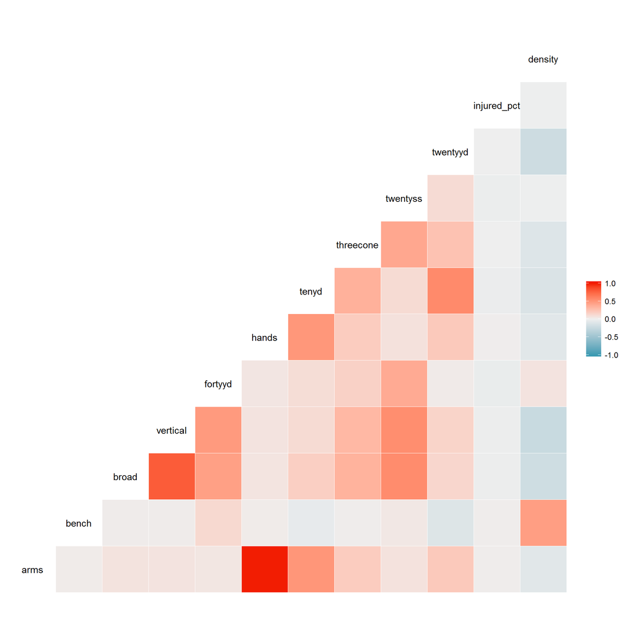

The strongest correlations are between arms and hand size (0.995) and broad and vertical jump (0.79). There were also lesser correlations between 10-yd and 20-yd dash (0.565), broad jump and 20-yd short shuttle (0.556), and vertical jump and 20-yd short shuttle (0.545). Most of these were to be expected, as the measurements were similar (for example arms and hand size), but I did find the correlation between the jumping measurements and the short shuttle to be interesting. It’s not a super strong correlation, but maybe worth looking into a little closer.

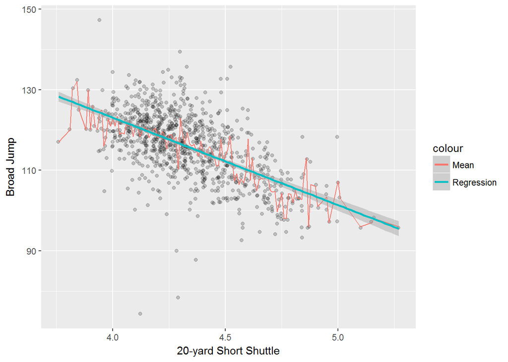

```
## [1] 0.5563638
```

Just looking at the scatter plot, it’s a little hard to see much correlation, but it’s much clearer with the mean and regression lines. The correlation appears to be negative, but remember that lower times in the short shuttle are actually better, so someone better (lower time) at the short shuttle generally seems to also be better (higher in inches) at the broad jump. Now let’s look at two pairs of variables that are more closely correlated.

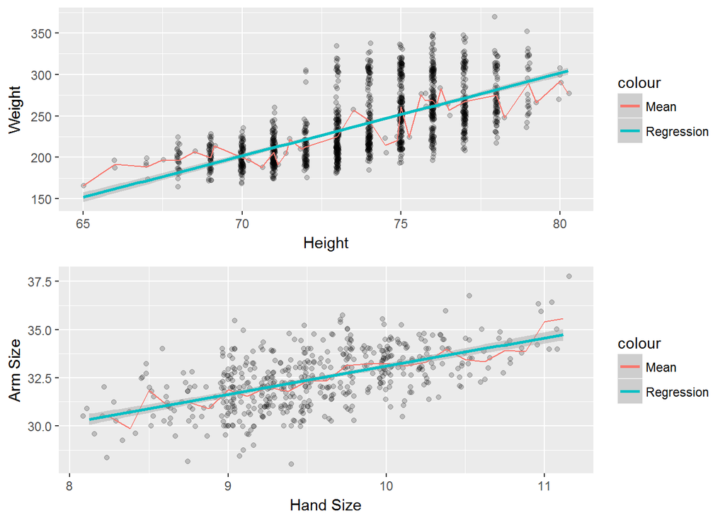

```
## [1] "Height to weight:"
```

```
## [1] 0.6549439
```

```
## [1] "Hand to arm size:"
```

```
## [1] 0.9949129
```

Both of these are very strong positive correlations, which you can see really clearly with the scatter plot but also with the mean and regression lines. These make sense too–you would logically assume someone with bigger hands to also have bigger arms, and taller people tend to be heavier as well.

Now lets look at how a player’s position is related to these other measurements, starting with injured percentage.

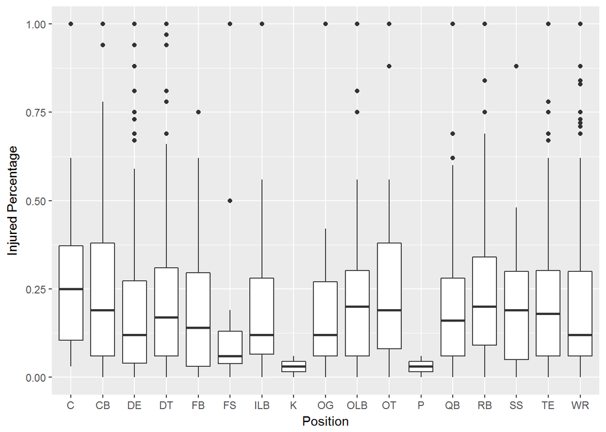

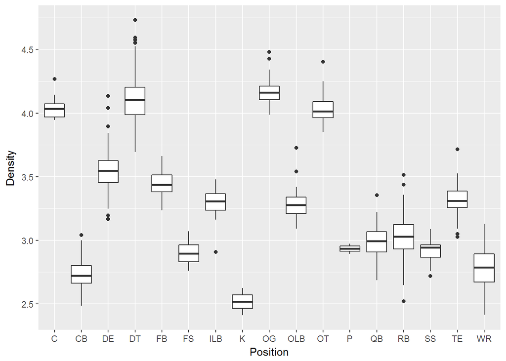

This one appears to be all over the place. Center, defensive tackle, offensive guard, and offensive tackle all are quite dense (higher density score), while kicker, cornerback, and wide receivers are all generally quite lean (lower density score).

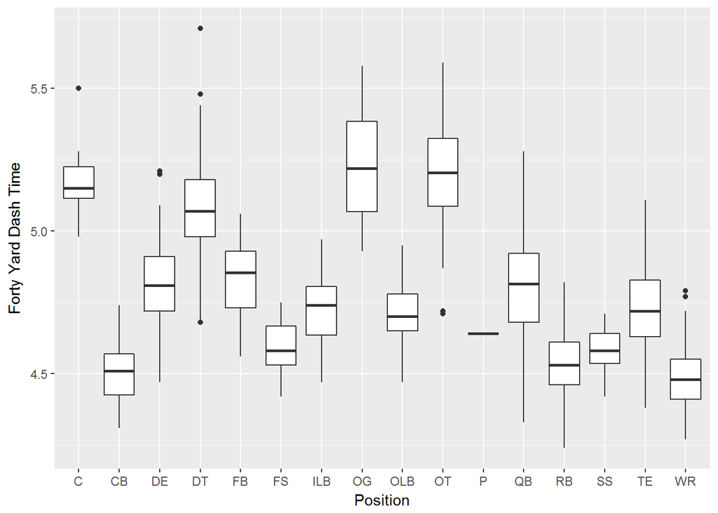

Here we again have definite groupings. Wide receivers and cornerbacks have the fastest times (possibly correlated to their leaner body types–we’ll look at that in the next section), while offensive guards and tackles have the slowest 40 times.

Now let’s look at some player statistic correlations, starting with [AV (approximate value)](https://www.pro-football-reference.com/blog/index37a8.html), a custom statistic from Pro Football Reference which attempts to gauge a player’s value per season.

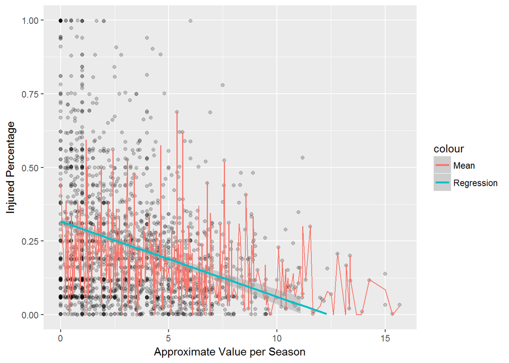

```
## [1] -0.3065318
```

Clearly a definite correlation here (-0.31)–as injured percentage goes up, a player’s value goes down. This is to be expected, as the less time a player is on the field, the less value he can bring his team. This is interesting though because it quantifies how much injury affects a player’s value.

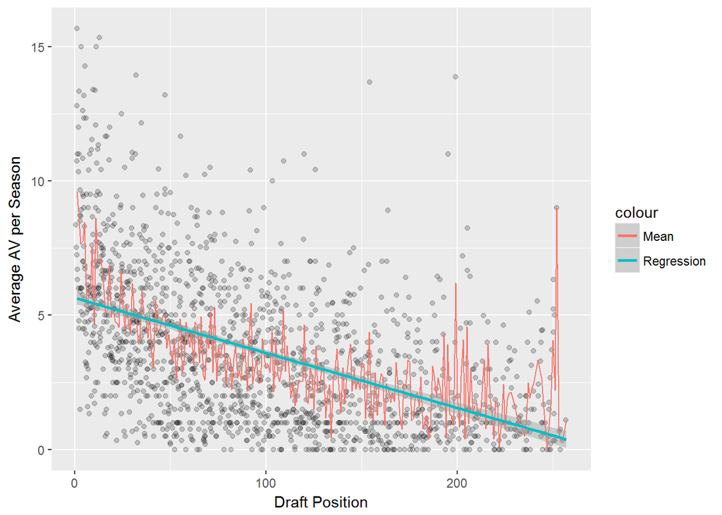

```
## [1] -0.4851426
```

This one is fascinating to me. There’s a clear and strong correlation (-0.49) between where a player is selected in the draft, and the value he provides to his team throughout his career.

Now let’s try combining our datasets, and see how some of our combine measurements correlate with draft position and performance metrics.

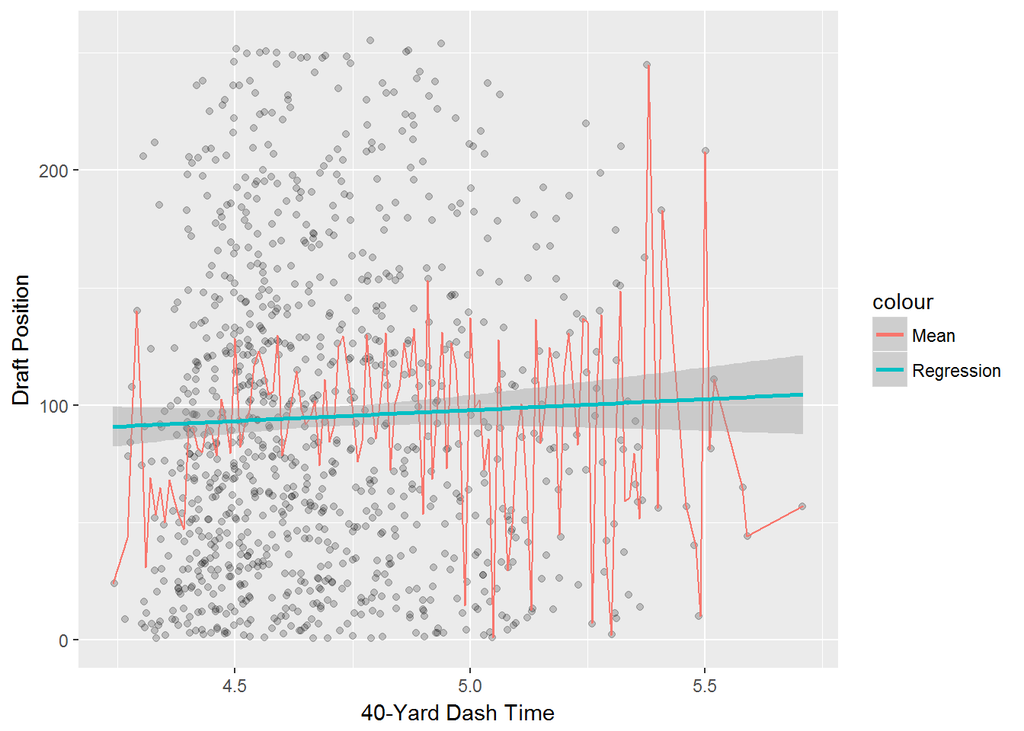

```
## [1] 0.001180111
```

Very slight correlation here–I’m guessing this is something that would make more sense to group by position, which we’ll do in the next section.

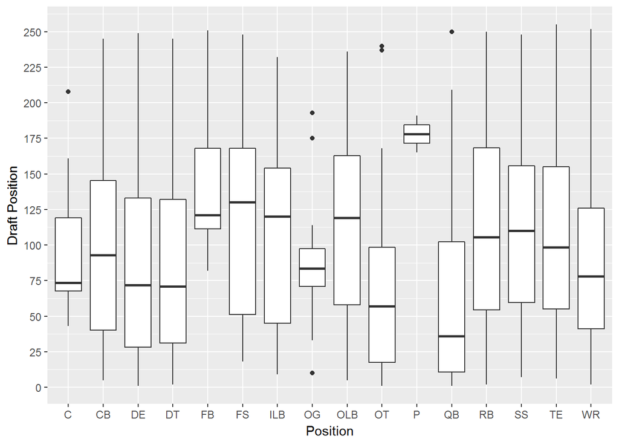

# Bivariate Analysis

### Talk about some of the relationships you observed in this part of the investigation. How did the feature(s) of interest vary with other features in the dataset?

Injury rates showed direct correlation with player position, draft position, and approximate value. With player position, it was clear that certain positions, such as kicker and punter, had much lower injury rates than others, and there appeared to be significant variation in injury rates even among the other positions. With player age, a relationship with injury rates did not start to present itself until players reached about 31 years of age or older, but then tapered off again after age 37 or so. I do think there is possiblity of finding better correlations with injury rates in multivariate analysis, which we’ll do in the next section.

### Did you observe any interesting relationships between the other features (not the main feature(s) of interest)?

I thought the relationship between player position and injured percentage, body density, and forty-yard dash times was fascinating. There were clear groupings among positions and even position types (i.e. offensive linemen vs. defensive backs). I’m particulary interested in seeing what we can see with positions in multivariate analysis. The relationships between player position and draft position were also interested–I’m very interested to see how that looks when combined with different combine measurements. Oh, and the relationship between draft position and approximate value was fascinating to me. I’d like to examine that with some other variables as well, maybe player position.

### What was the strongest relationship you found?

# Multivariate Plots Section

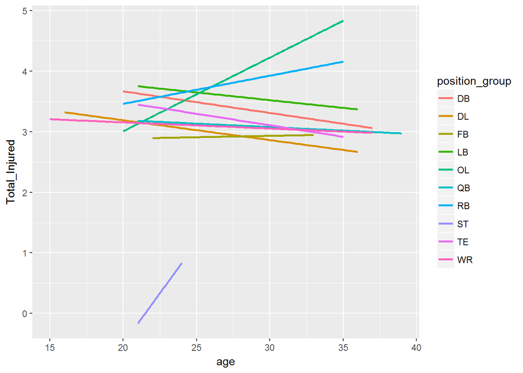

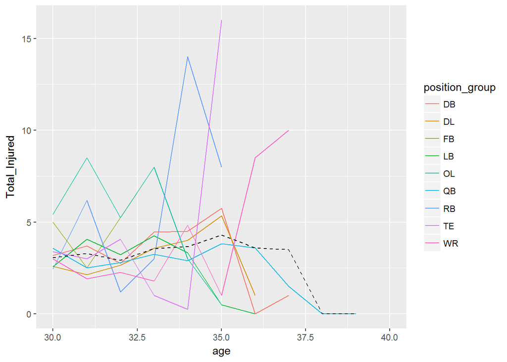

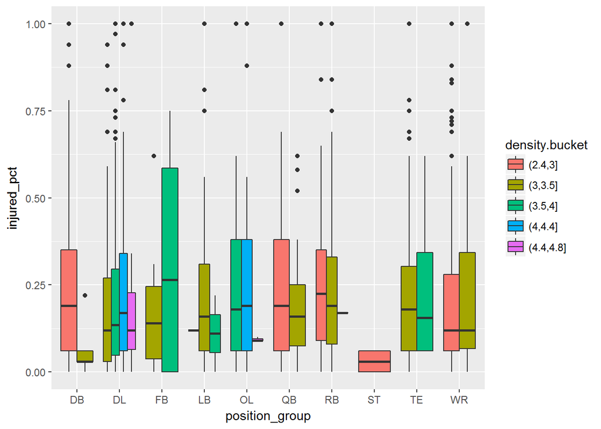

This is another look at injury rates by position, this time with density thrown in as another variable. It’s very easy to see the differences between the lighter and heavier position groupings. From this look, the effect of density on injury rates by position group appears almost random–for some injury rates tend to increase as density increases, and for others, the relationship is the inverse of that.

Now let’s look at how combine measurements affect when a player is drafted, controlling for player position this time.

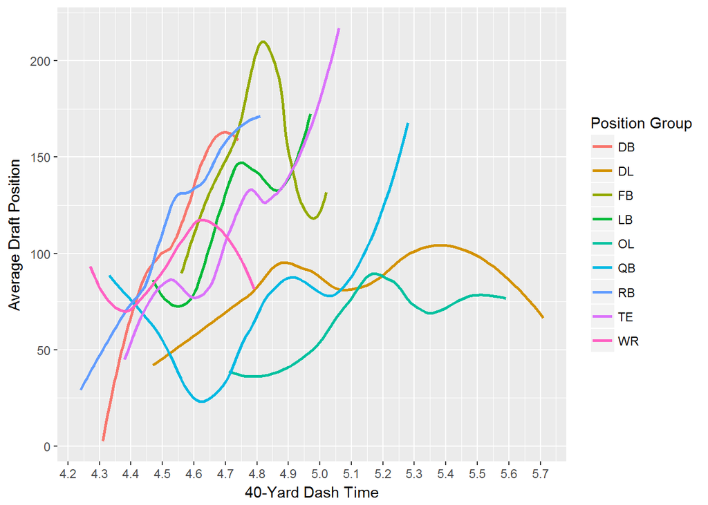

Here we can see that for most position groupings, as a player’s 40-yard dash time increases, his draft position tends to increase as well (meaning he’s drafted later). This is especially true for tight ends, defensive backs, linebackers, and running backs. For some of the other positions, it seems to go up and down. For wide receivers, for example, between about 4.35 and 4.6, there’s a strong positive correlation between 40-yard times and draft position. below and above those points, however, the correlation appears to be negative. This seems counterintuitive, but my guess is it’s because there aren’t that many players drafted with 40-times in that range, so it’s more subject to statistical variance.

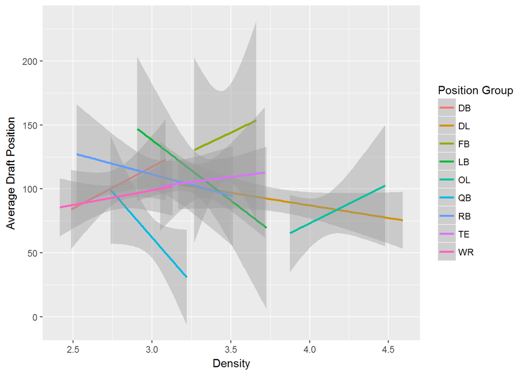

Density is interesting when looked at by position, because it would seem that higher density is good for certain position groups and bad for others. For running backs, for example, the denser players tend to be drafted earlier. For offensive linemen, on the other hand, denser players tend to be drafted later.